# advancedR_learning

KJY

2022-01-01

```r
library(tidyverse)
```

A functional is a function that takes a function as an input and returns a vector as output.

```r
randomise <- function(f) f(runif(1e3))
randomise(mean)
```

```
## [1] 0.4979946
```

passed mean function to the randomise functipn, which equal

```r
mean(runif(1e3))
```

```
## [1] 0.5067506
```

```r
library(purrr)

triple <- function(x) x * 3
map(1:3, triple) # map the list to triple function
```

```
## [[1]]
## [1] 3
##
## [[2]]
## [1] 6
##
## [[3]]
## [1] 9
```

map() defines a mapping from one vector to another. (“Map” also has the nice property of being short, which is useful for such a fundamental building block.)

```r
simple_map <- function(x, f, ...) {
  out <- vector("list", length(x))
  for (i in seq_along(x)) {
    out[[i]] <- f(x[[i]], ...)
  }
  out
}
```

```r
# vector produces a vector of the given length and mode.

vector("list", 3) # creat three list
```

[output not shown]

```r
seq_along(1:3)
```

```
## [1] 1 2 3
```

```r
simple_map(1:3, triple)
```

```
## [[1]]
## [1] 3
##
## [[2]]
## [1] 6
##
## [[3]]
## [1] 9
```

each column in mtcars is a list, so can pass value into map function

```r
n_unique <- function(x) length(unique(x))
map_int(mtcars, n_unique)
```

```
##  mpg  cyl disp   hp drat   wt qsec   vs   am gear carb
##   25    3   27   22   22   29   30    2    2    3    6
```

```r
# pair <- function(x) c(x, x)
# map_dbl(1:2, pair)
```

to fix it:

```r
pair <- function(x) (x+x)
map_dbl(1:2, pair)
```

```
## [1] 2 4
```

besides, we also albe to switch back to map(), because map() can accept any type of output.

```r
pair <- function(x) c(x, x)
map(1:2, pair)
```

```
## [[1]]
## [1] 1 1
##
## [[2]]
## [1] 2 2
```

Anonymous functions and shortcuts

```r
map_dbl(mtcars, function(x) length(unique(x)))
```

```
##  mpg  cyl disp   hp drat   wt qsec   vs   am gear carb
##   25    3   27   22   22   29   30    2    2    3    6
```

```r
# equal to the shortcuts
map_dbl(mtcars, ~ length(unique(.x)))
```

```
##  mpg  cyl disp   hp drat   wt qsec   vs   am gear carb
##   25    3   27   22   22   29   30    2    2    3    6
```

```r
as_mapper(~ length(unique(.x)))
```

```
## <lambda>
## function (..., .x = ..1, .y = ..2, . = ..1)
## length(unique(.x))
## attr(,"class")
## [1] "rlang_lambda_function" "function"
```

```r
x <- map(1:3, ~ runif(2))
str(x)
```

```
## List of 3
##  $ : num [1:2] 0.00691 0.30997
##  $ : num [1:2] 0.349 0.557
##  $ : num [1:2] 0.188 0.856
```

```r
as_mapper(~ runif(2))
```

```
## <lambda>
## function (..., .x = ..1, .y = ..2, . = ..1)
## runif(2)
## attr(,"class")
## [1] "rlang_lambda_function" "function"
```

```r
x <- list(
  list(-1, x = 1, y = c(2), z = "a"),
  list(-2, x = 4, y = c(5, 6), z = "b"),
  list(-3, x = 8, y = c(9, 10, 11))
)

x
```

```
## [[1]]
## [[1]][[1]]
## [1] -1
##
## [[1]]$x
## [1] 1
##
## [[1]]$y
## [1] 2
##
## [[1]]$z
## [1] "a"
##
##
## [[2]]
## [[2]][[1]]
## [1] -2
##
## [[2]]$x
## [1] 4
##
## [[2]]$y
## [1] 5 6
##
## [[2]]$z
## [1] "b"
##
##
## [[3]]
## [[3]][[1]]
## [1] -3
##
## [[3]]$x
## [1] 8
##
## [[3]]$y
## [1]  9 10 11
```

```r
# Select by name
map_dbl(x, "x")
```

```
## [1] 1 4 8
```

```r
# Or by both
map_dbl(x, list("y", 1))
```

```
## [1] 2 5 9
```

```r
simple_map <- function(x, f, ...) {
  out <- vector("list", length(x))
  for (i in seq_along(x)) {
    out[[i]] <- f(x[[i]], ...)
  }
  out
}
```

```r
# boostrap_summary <- function(x, f) {
#   f(sample(x, replace = TRUE))
# }
#
# simple_map(mtcars, boostrap_summary, f = mean)
```

simple_map() has arguments x and f so you’ll have problems whenever the function you are calling has arguments x or f:

```r
simple_map <- function(.x, .f, ...) {
  out <- vector("list", length(.x))
  for (i in seq_along(.x)) {
    out[[i]] <- .f(.x[[i]], ...)
  }
  out
}
```

```r
boostrap_summary <- function(x, f) {
  f(sample(x, replace = TRUE))
}

simple_map(mtcars, boostrap_summary, f = mean)
```

```
## [[1]]
## [1] 19.5875
##
## [[2]]
## [1] 5.6875
##
## [[3]]
## [1] 254.4969
##
## [[4]]
## [1] 156.0938
##
## [[5]]
## [1] 3.702812
##
## [[6]]
## [1] 3.267969
##
## [[7]]
## [1] 18.01281
##
## [[8]]
## [1] 0.4375
##
## [[9]]
## [1] 0.4375
##
## [[10]]
## [1] 3.5625
##
## [[11]]
## [1] 2.75
```

```r
trims <- c(0, 0.1, 0.2, 0.5)
x <- rcauchy(1000)
```

```r
map_dbl(trims, ~ mean(x, trim = .x))
```

```
## [1] -0.05776363  0.04962785  0.04053066  0.01843051
```

```r
map_dbl(trims, function(trim) mean(x, trim = trim))
```

```
## [1] -0.05776363  0.04962785  0.04053066  0.01843051
```

```r
# trim: the fraction (0 to 0.5) of observations to be trimmed from each end of x before the mean is computed. Values of trim outside that range are taken as the nearest endpoint.
```

```r
mean(x, trim = 0.1)
```

```
## [1] 0.04962785
```

```r
mean(0.1, x = x)
```

```
## [1] 0.04962785
```

```r
by_cyl <- split(mtcars, mtcars$cyl)
by_cyl
```

```
## $`4`
##                 mpg cyl  disp  hp drat    wt  qsec vs am gear carb
## Datsun 710     22.8   4 108.0  93 3.85 2.320 18.61  1  1    4    1
## Merc 240D      24.4   4 146.7  62 3.69 3.190 20.00  1  0    4    2
## Merc 230       22.8   4 140.8  95 3.92 3.150 22.90  1  0    4    2
## Fiat 128       32.4   4  78.7  66 4.08 2.200 19.47  1  1    4    1
## Honda Civic    30.4   4  75.7  52 4.93 1.615 18.52  1  1    4    2
## Toyota Corolla 33.9   4  71.1  65 4.22 1.835 19.90  1  1    4    1
## Toyota Corona  21.5   4 120.1  97 3.70 2.465 20.01  1  0    3    1
## Fiat X1-9      27.3   4  79.0  66 4.08 1.935 18.90  1  1    4    1
## Porsche 914-2  26.0   4 120.3  91 4.43 2.140 16.70  0  1    5    2
## Lotus Europa   30.4   4  95.1 113 3.77 1.513 16.90  1  1    5    2
## Volvo 142E     21.4   4 121.0 109 4.11 2.780 18.60  1  1    4    2
##
## $`6`
##                 mpg cyl  disp  hp drat    wt  qsec vs am gear carb
## Mazda RX4      21.0   6 160.0 110 3.90 2.620 16.46  0  1    4    4
## Mazda RX4 Wag  21.0   6 160.0 110 3.90 2.875 17.02  0  1    4    4
## Hornet 4 Drive 21.4   6 258.0 110 3.08 3.215 19.44  1  0    3    1
## Valiant        18.1   6 225.0 105 2.76 3.460 20.22  1  0    3    1
## Merc 280       19.2   6 167.6 123 3.92 3.440 18.30  1  0    4    4
## Merc 280C      17.8   6 167.6 123 3.92 3.440 18.90  1  0    4    4
## Ferrari Dino   19.7   6 145.0 175 3.62 2.770 15.50  0  1    5    6
##
## $`8`
##                      mpg cyl  disp  hp drat    wt  qsec vs am gear carb
## Hornet Sportabout   18.7   8 360.0 175 3.15 3.440 17.02  0  0    3    2
## Duster 360          14.3   8 360.0 245 3.21 3.570 15.84  0  0    3    4
## Merc 450SE          16.4   8 275.8 180 3.07 4.070 17.40  0  0    3    3
## Merc 450SL          17.3   8 275.8 180 3.07 3.730 17.60  0  0    3    3
## Merc 450SLC         15.2   8 275.8 180 3.07 3.780 18.00  0  0    3    3
## Cadillac Fleetwood  10.4   8 472.0 205 2.93 5.250 17.98  0  0    3    4
## Lincoln Continental 10.4   8 460.0 215 3.00 5.424 17.82  0  0    3    4
## Chrysler Imperial   14.7   8 440.0 230 3.23 5.345 17.42  0  0    3    4
## Dodge Challenger    15.5   8 318.0 150 2.76 3.520 16.87  0  0    3    2
## AMC Javelin         15.2   8 304.0 150 3.15 3.435 17.30  0  0    3    2
## Camaro Z28          13.3   8 350.0 245 3.73 3.840 15.41  0  0    3    4
## Pontiac Firebird    19.2   8 400.0 175 3.08 3.845 17.05  0  0    3    2
## Ford Pantera L      15.8   8 351.0 264 4.22 3.170 14.50  0  1    5    4
## Maserati Bora       15.0   8 301.0 335 3.54 3.570 14.60  0  1    5    8
```

```r
class(by_cyl)
```

```
## [1] "list"
```

```r
by_cyl$`4`
```

```
##                 mpg cyl  disp  hp drat    wt  qsec vs am gear carb
## Datsun 710     22.8   4 108.0  93 3.85 2.320 18.61  1  1    4    1
## Merc 240D      24.4   4 146.7  62 3.69 3.190 20.00  1  0    4    2
## Merc 230       22.8   4 140.8  95 3.92 3.150 22.90  1  0    4    2
## Fiat 128       32.4   4  78.7  66 4.08 2.200 19.47  1  1    4    1
## Honda Civic    30.4   4  75.7  52 4.93 1.615 18.52  1  1    4    2
## Toyota Corolla 33.9   4  71.1  65 4.22 1.835 19.90  1  1    4    1
## Toyota Corona  21.5   4 120.1  97 3.70 2.465 20.01  1  0    3    1
## Fiat X1-9      27.3   4  79.0  66 4.08 1.935 18.90  1  1    4    1
## Porsche 914-2  26.0   4 120.3  91 4.43 2.140 16.70  0  1    5    2
## Lotus Europa   30.4   4  95.1 113 3.77 1.513 16.90  1  1    5    2
## Volvo 142E     21.4   4 121.0 109 4.11 2.780 18.60  1  1    4    2
```

modify(), which always returns the same type of output as the input:

```r
df <- data.frame(
  x = 1:3,
  y = 6:4
)

map(df, ~ .x * 2)
```

```
## $x
## [1] 2 4 6
##
## $y
## [1] 12 10  8
```

```r
modify(df, ~ .x *2)
```

```
##   x  y
## 1 2 12
## 2 4 10
## 3 6  8
```

```r
xs <- map(1:8, ~ runif(10))
xs[[1]][[1]] <- NA
ws <- map(1:8, ~ rpois(10, 5) + 1)
```

```r
xs; ws
```

```
## [[1]]
##  [1]        NA 0.9254684 0.1384868 0.4474781 0.6261945 0.7370833 0.3292617
##  [8] 0.0829927 0.3954472 0.5891615
##
## [[2]]
##  [1] 0.0854721977 0.3096823420 0.4781062726 0.8077565343 0.7736784257
##  [6] 0.7292714571 0.0001353056 0.6091535545 0.2639012663 0.4935492554
##
## [[3]]
##  [1] 0.7026315 0.3790759 0.2970907 0.2641558 0.4364809 0.1888644 0.2988418
##  [8] 0.4484593 0.1767150 0.8430935
##
## [[4]]
##  [1] 0.7898921 0.9507590 0.9939489 0.6728197 0.6836260 0.4677084 0.7768418
##  [8] 0.2358385 0.4388260 0.4258859
##
## [[5]]
##  [1] 0.84172627 0.40526144 0.00141943 0.91678336 0.67677306 0.70992855
##  [7] 0.08504161 0.42768983 0.90040995 0.49442071
##
## [[6]]
##  [1] 0.23819056 0.70060846 0.74093601 0.67877310 0.23985596 0.19510922
##  [7] 0.07317876 0.45149289 0.72927307 0.44702736
##
## [[7]]
##  [1] 0.89201956 0.05951033 0.39226807 0.89532749 0.46051096 0.74078780
##  [7] 0.39943412 0.46700671 0.23819476 0.17868671
##
## [[8]]
##  [1] 0.05959653 0.67852024 0.63288680 0.27807686 0.42942337 0.44412972
##  [7] 0.45099269 0.29940541 0.36091423 0.45618399
```

```
## [[1]]
##  [1] 8 6 6 7 7 3 4 4 5 5
##
## [[2]]
##  [1] 5 8 9 3 4 9 3 5 6 4
##
## [[3]]
##  [1]  8  5  8 11  4 11  8  4  4  6
##
## [[4]]
##  [1] 5 8 4 7 9 8 9 7 4 7
##
## [[5]]
##  [1] 7 5 3 4 5 9 5 8 4 7
##
## [[6]]
##  [1] 10  4 12 12  9  5  4  8  6  7
##
## [[7]]
##  [1] 6 7 3 5 7 7 5 2 4 5
##
## [[8]]
##  [1]  5 10  8  5  7 10  5  9  4  5
```

```r
map2_dbl(xs, ws, weighted.mean, na.rm = TRUE)
```

```
## [1] 0.4826117 0.4623747 0.3851057 0.6399164 0.5661810 0.4774622 0.4825219
## [8] 0.4361487
```

```r
x <- map(1:6, ~ sample(1000, 10))
x
```

```
## [[1]]
##  [1] 712 498 283 173 525 442 120 320  26 903
##
## [[2]]
##  [1] 272 565 110 671 397 216 284 356 890 485
##
## [[3]]
##  [1] 400 461 902 712 399 950 728  37 524 972
##
## [[4]]
##  [1] 670 979 905 296 262  36 200 737 404 148
##
## [[5]]
##  [1] 495  53 983 906  57 805 251  91 844 394
##
## [[6]]
##  [1] 150 418 926  81 696 801 929 121 196 674
```

```r
imap_chr(x, ~ paste0("The highest value of ", .y, " is ", max(.x)))
```

```
## [1] "The highest value of 1 is 903" "The highest value of 2 is 890"
## [3] "The highest value of 3 is 972" "The highest value of 4 is 979"
## [5] "The highest value of 5 is 983" "The highest value of 6 is 929"
```

```r
params <- tibble::tribble(
  ~ n, ~ min, ~ max,
   1L,     0,     1,
   2L,    10,   100,
   3L,   100,  1000
)

params
```

```
## # A tibble: 3 x 3
##       n   min   max
##   <int> <dbl> <dbl>
## 1     1     0     1
## 2     2    10   100
## 3     3   100  1000
```

```r
pmap(params, runif)
```

```
## [[1]]
## [1] 0.2535985
##
## [[2]]
## [1] 54.66417 25.99152
##
## [[3]]
## [1] 357.0045 151.5599 637.8662
```

```r
runif(3, 100, 1000)
```

```
## [1] 474.1963 396.0230 155.3052
```

```r
x <- c(4, 3, 10)
reduce(x, `+`)
```

```
## [1] 17
```

```r
accumulate(x, `+`)
```

```
## [1]  4  7 17
```

```r
x <- 10
f1 <- function(x) {
  function() {
    x + 10
  }
}
f1(1)()
```

```
## [1] 11
```

```r
f1(1)
```

```
## function() {
##     x + 10
##   }
## <bytecode: 0x7f8a7fbaea98>
## <environment: 0x7f8a82ad9118>
```

```r
x <- 10
g01 <- function() {
  x <- 20
  x
}

g01()
```

```
## [1] 20
```

```r
i01 <- function(y, z) {
  list(y = y, z = z)
}

i02 <- function(x, ...) {
  i01(...)
}

(i02(x = 1, y = 2, z = 3))
```

```
## $y
## [1] 2
##
## $z
## [1] 3
```

```r
j04 <- function() invisible(1)

j04()
```

```r
j04 <- function() 1

j04()
```

```
## [1] 1
```

```r
(a <- 2)
```

```
## [1] 2
```

```r
a <- b <- c <- d <- 2

a; b; c; d
```

```
## [1] 2
```

```
## [1] 2
```

```
## [1] 2
```

```
## [1] 2
```

```r
# j05 <- function() {
#
#   stop("I'm an error")
#
#   return(10)
#
# }
#
# j05()
```

```r
j05 <- function() {

  return(10)

}

j05()
```

```
## [1] 10
```

Replacement functions Replacement functions act like they modify their arguments in place, and have the special name xxx<-.

```r
`second<-` <- function(x, value) {

  x[2] <- value

  x

}
```

```r
x <- 1:10

second(x) <- 5L

x
```

```
##  [1]  1  5  3  4  5  6  7  8  9 10
```

```r
# second(x, 5)
```

```r
`modify<-` <- function(x, position, value) {

  x[position] <- value

  x

}

modify(x, 1) <- 10

x
```

```
##  [1] 10  5  3  4  5  6  7  8  9 10
```

```r
modify(x, 2) <- 10

x
```

```
##  [1] 10 10  3  4  5  6  7  8  9 10
```

```r
x <- c(a = 1, b = 2, c = 3)

x
```

```
## a b c
## 1 2 3
```

```r
names(x)
```

```
## [1] "a" "b" "c"
```

```r
library(rlang) # Functions for Base Types and Core R and 'Tidyverse' Features
# A toolbox for working with base types, core R features like the condition system, and core 'Tidyverse' features like tidy evaluation.
```

The job of an environment is to associate, or bind, a set of names to a set of values.

```r
e1 <- env(
  a = FALSE,
  b = "a",
  c = 2.3,
  d = 1:3,
)
```

```r
e1
```

```
## <environment: 0x7f8a87daa0a8>
```

```r
e1$d <- e1
e1
```

```
## <environment: 0x7f8a87daa0a8>
```

```r
env_print(e1)
```

```
## <environment: 0x7f8a87daa0a8>
## parent: <environment: global>
## bindings:
##  * a: <lgl>
##  * b: <chr>
##  * c: <dbl>
##  * d: <env>
```

```r
env_names(e1)
```

```
## [1] "a" "b" "c" "d"
```

To compare environments, you need to use identical() and not ==. This is because == is a vectorised operator, and environments are not vectors.

```r
identical(global_env(), current_env())
```

```
## [1] TRUE
```

```r
e2a <- env(d = 4, e = 5)
e2b <- env(e2a, a = 1, b = 2, c = 3)
```

```r
env_parent(e2b)
```

```
## <environment: 0x7f8a85d59a80>
```

```r
env_parent(e2a)
```

```
## <environment: R_GlobalEnv>
```

```r
env_parents(e2b, last = empty_env())
```

```
##  [[1]]   <env: 0x7f8a85d59a80>
##  [[2]] $ <env: global>
##  [[3]] $ <env: package:rlang>
##  [[4]] $ <env: package:forcats>
##  [[5]] $ <env: package:stringr>
##  [[6]] $ <env: package:dplyr>
##  [[7]] $ <env: package:purrr>
##  [[8]] $ <env: package:readr>
##  [[9]] $ <env: package:tidyr>
## [[10]] $ <env: package:tibble>
## [[11]] $ <env: package:ggplot2>
## [[12]] $ <env: package:tidyverse>
## [[13]] $ <env: package:stats>
## [[14]] $ <env: package:graphics>
## [[15]] $ <env: package:grDevices>
## [[16]] $ <env: package:utils>
## [[17]] $ <env: package:datasets>
## [[18]] $ <env: package:methods>
## [[19]] $ <env: Autoloads>
## [[20]] $ <env: package:base>
## ... and 1 more environments
```

```r
x <- 0
f <- function() {
  x <<- 1
}
f()
x
```

```
## [1] 1
```

```r
x <- 0
f <- function() {
  x <<- 1
}
# f() if not run this, x will still 0
x
```

```
## [1] 0
```

can get and set elements of an environment with $ and [[ in the same way as a list:

```r
e3 <- env(x = 1, y = 2)
e3$x
```

```
## [1] 1
```

```r
env_get(e3, "x")
```

```
## [1] 1
```

env_poke()42 takes a name (as string) and a value:

env_bind() allows you to bind multiple values:

```r
env_poke(e3, "a", 100)
e3$a
```

```
## [1] 100
```

```r
env_bind(e3, a = 10, b = 20)
env_names(e3)
```

```
## [1] "x" "y" "a" "b"
```

```r
env_unbind(e3, "a")

env_has(e3, "a")
```

```
##     a
## FALSE
```

```r
# 定义teacher对象和行为
teacher <- function(x,...) UseMethod("teacher")
teacher.lecture <- function(x,...) print("上课")
teacher.assignment <- function(x,...) print("布置作业")
teacher.correcting <- function(x,...) print("批改作业")
teacher.default <- function(x,...) print("你不是teacher")

# 定义同学对象和行为

student <- function(x,...) UseMethod("student")
student.attend <- function(x,...) print("听课")
student.homework <- function(x,...) print("写作业")
student.exam <- function(x,...) print("考试")
student.default <- function(x,...) print("你不是student")

#定义两个变量，a老师和b同学

a <- 'teacher' # now, a is still character
class(a)
```

```
## [1] "character"
```

```r
b <- 'student'

# 给老师变量设置行为

attr(a,"class") <- 'lecture'


class(a)  # now a is a lecture
```

```
## [1] "lecture"
```

```r
a
```

```
## [1] "teacher"
## attr(,"class")
## [1] "lecture"
```

```r
# 执行老师的行为
teacher(a)
```

```
## [1] "上课"
```

```r
attr(a,'class') <- 'assignment'

class(a)
```

```
## [1] "assignment"
```

```r
teacher(a)
```

```
## [1] "布置作业"
```

```r
where <- function(name, env = caller_env()) {
  if (identical(env, empty_env())) {
    # Base case
    stop("Can't find ", name, call. = FALSE)
  } else if (env_has(env, name)) {
    # Success case
    env
  } else {
    # Recursive case
    where(name, env_parent(env))
  }
}
```

```r
# where("yyy")
```

```r
x <- 5
where("x")
```

```
## <environment: R_GlobalEnv>
```

```r
where("mean")
```

```
## <environment: base>
```

package environments

```r
search()
```

```
##  [1] ".GlobalEnv"        "package:rlang"     "package:forcats"
##  [4] "package:stringr"   "package:dplyr"     "package:purrr"
##  [7] "package:readr"     "package:tidyr"     "package:tibble"
## [10] "package:ggplot2"   "package:tidyverse" "package:stats"
## [13] "package:graphics"  "package:grDevices" "package:utils"
## [16] "package:datasets"  "package:methods"   "Autoloads"
## [19] "package:base"
```

```r
search_envs()
```

```
##  [[1]] $ <env: global>
##  [[2]] $ <env: package:rlang>
##  [[3]] $ <env: package:forcats>
##  [[4]] $ <env: package:stringr>
##  [[5]] $ <env: package:dplyr>
##  [[6]] $ <env: package:purrr>
##  [[7]] $ <env: package:readr>
##  [[8]] $ <env: package:tidyr>
##  [[9]] $ <env: package:tibble>
## [[10]] $ <env: package:ggplot2>
## [[11]] $ <env: package:tidyverse>
## [[12]] $ <env: package:stats>
## [[13]] $ <env: package:graphics>
## [[14]] $ <env: package:grDevices>
## [[15]] $ <env: package:utils>
## [[16]] $ <env: package:datasets>
## [[17]] $ <env: package:methods>
## [[18]] $ <env: Autoloads>
## [[19]] $ <env: package:base>
```

```r
e <- env()
e$g <- function() 1
```

```r
# cannot directly get g functions
# g()
e$g()
```

```
## [1] 1
```

Every function in a package is associated with a pair of environments: the package environment, which you learned about earlier, and the namespace environment.

```r
sd # so sd in the environment and have a namespace
```

```
## function (x, na.rm = FALSE)
## sqrt(var(if (is.vector(x) || is.factor(x)) x else as.double(x),
##     na.rm = na.rm))
## <bytecode: 0x7f8a8868ab70>
## <environment: namespace:stats>
```

```r
library(rlang)
library(ggplot2)
library(scales)
power1 <- function(exp) {
  function(x) {x ^ exp}
}

square <- power1(2)
cube <- power1(3)
```

```r
square
```

```
## function(x) {x ^ exp}
## <environment: 0x7f8a898c0bf0>
```

```r
cube
```

```
## function(x) {x ^ exp}
## <bytecode: 0x7f8a87dd2930>
## <environment: 0x7f8a8940b1f0>
```

how does R find the value associated with exp

```r
env_print(square); env_print(cube)
```

```
## <environment: 0x7f8a898c0bf0>
## parent: <environment: global>
## bindings:
##  * exp: <lazy>
```

```
## <environment: 0x7f8a8940b1f0>
## parent: <environment: global>
## bindings:
##  * exp: <lazy>
```

```r
a <- fn_env(square)
```

```r
a$exp
```

```
## [1] 2
```

```r
fn_env(cube)$exp
```

```
## [1] 3
```

```r
power1 <- function(exp) {
  function(x) {x ^ exp}
}

x <- 2
square <- power1(x) # square (x^2), now exp not give to 2

x <- 3 # now x is 3

square(2) # load here, so x is 3 now
```

```
## [1] 8
```

because x is only evaluated lazily when square() is run, not when power1() is run.

```r
power1 <- function(exp) {
  function(x) {x ^ exp}
}

x <- 2
square <- power1(x) # square (x^2)

square(2) # now x is given to exp, and become 2, results is 4
```

```
## [1] 4
```

```r
x <- 3

square(2) # still results is 4
```

```
## [1] 4
```

```r
power2 <- function(exp) {
  force(exp)
  function(x) {
    x ^ exp
  }
}

x <- 2
square <- power2(x)
x <- 3
square(2)
```

```
## [1] 4
```

```r
new_counter <- function() {
  i <- 0

  function() {
    i <<- i + 1
    i
  }
}

counter_one <- new_counter()
counter_two <- new_counter()
```

```r
counter_one()
```

```
## [1] 1
```

```r
counter_one()
```

```
## [1] 2
```

```r
new_counter <- function() {
  i <- 0

  function() {
    i <- i + 1
    i
  }
}

counter_one <- new_counter()
counter_two <- new_counter()
```

```r
counter_one()
```

```
## [1] 1
```

```r
counter_one()
```

```
## [1] 1
```

```r
y <- c(12345, 123456, 1234567)

comma_format()(y)
```

```
## [1] "12,345"    "123,456"   "1,234,567"
```

```r
comma_format(y)
```

```
## function (x)
## number(x, accuracy = accuracy, scale = scale, prefix = prefix,
##     suffix = suffix, big.mark = big.mark, decimal.mark = decimal.mark,
##     trim = trim, ...)
## <bytecode: 0x7f8a87995078>
## <environment: 0x7f8a87a15628>
```

```r
comma_format
```

```
## function (accuracy = NULL, scale = 1, prefix = "", suffix = "",
##     big.mark = ",", decimal.mark = ".", trim = TRUE, digits,
##     ...)
## {
##     if (!missing(digits)) {
##         warning("`digits` argument is deprecated, use `accuracy` instead.",
##             .call = FALSE)
##     }
##     number_format(accuracy = accuracy, scale = scale, prefix = prefix,
##         suffix = suffix, big.mark = big.mark, decimal.mark = decimal.mark,
##         trim = trim, ...)
## }
## <bytecode: 0x7f8a87990dd8>
## <environment: namespace:scales>
```

```r
a <- comma_format() # a is a function now

a(y)
```

```
## [1] "12,345"    "123,456"   "1,234,567"
```

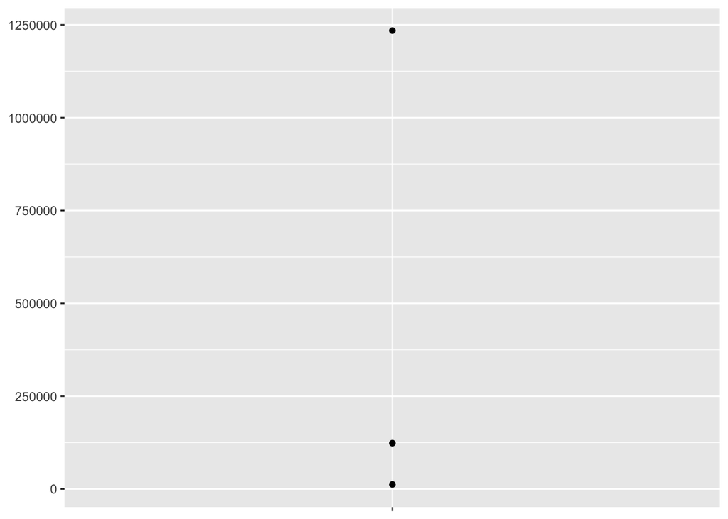

```r
df <- data.frame(x = 1, y = y)

core <- ggplot(df, aes(x, y)) +
  geom_point() +
  scale_x_continuous(breaks = 1, labels = NULL) +
  labs(x = NULL, y = NULL)

core
```

```r
core + scale_y_continuous(
  labels = comma_format()
)
```

[figure not shown]

```r
core + scale_y_continuous(
  labels = number_format(scale = 1e-3, suffix = " K")
)
```

[figure not shown]

```r
core + scale_y_continuous(
  labels = scientific_format()
)
```

[figure not shown]

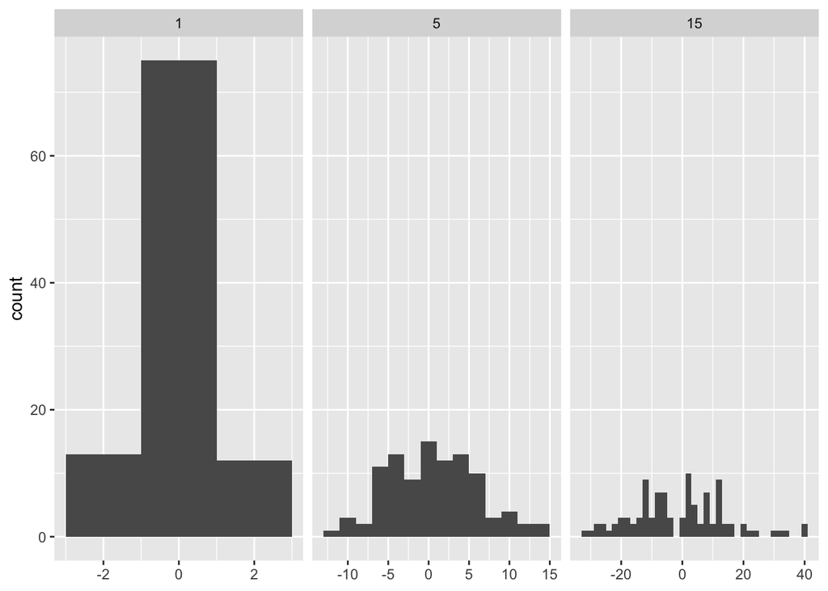

```r
# construct some sample data with very different numbers in each cell
sd <- c(1, 5, 15)
n <- 100

df <- data.frame(x = rnorm(3 * n, sd = sd), sd = rep(sd, n))

ggplot(df, aes(x)) +
  geom_histogram(binwidth = 2) +
  facet_wrap(~ sd, scales = "free_x") +
  labs(x = NULL)
```

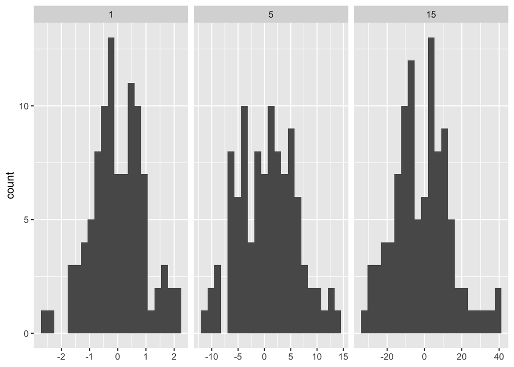

```r
binwidth_bins <- function(n) {
  force(n)

  function(x) {
    (max(x) - min(x)) / n
  }
}

ggplot(df, aes(x)) +
  geom_histogram(binwidth = binwidth_bins(20)) +
  facet_wrap(~ sd, scales = "free_x") +
  labs(x = NULL)
```

```r
a <- fn_env(binwidth_bins(20))

a$n
```

```
## [1] 20
```

```r
names <- list(
  square = 2,
  cube = 3,
  root = 1/2,
  cuberoot = 1/3,
  reciprocal = -1
)
funs <- purrr::map(names, power1)
```

```r
funs$square(64)
```

```
## [1] 4096
```

```r
with(funs, root(100))
```

```
## [1] 10
```

```r
# with(data, expr, ...)
# Evaluate an R expression in an environment constructed from data, possibly modifying (a copy of) the original data.

with(mtcars, mpg[cyl == 8  &  disp > 350])
```

```
## [1] 18.7 14.3 10.4 10.4 14.7 19.2 15.8
```

For a longer effect, you can attach() the functions to the search path, then detach() when you’re done:

```r
attach(funs)
# attach This means that the database is searched by R when evaluating a variable, so objects in the database can be accessed by simply giving their names.
root(100)
```

```
## [1] 10
```

A function operator is a function that takes one (or more) functions as input and returns a function as output.

If you’re familiar with Python, decorators is just another name for function operators.

装饰器(Decorators)是Python 的一个重要部分。 简单地说：他们是修改其他函数的功能的函数。 他们有助于让我们的代码更简短，也更Pythonic（Python范儿）。

```r
chatty <- function(f) {
  force(f)

  function(x, ...) {
    res <- f(x, ...)
    cat("Processing ", x, "\n", sep = "")
    res
  }
} ## return a function


f <- function(x) x ^ 2

s <- c(3, 2, 1)

purrr::map_dbl(s, chatty(f)) # map list to the functions
```

```
## Processing 3
## Processing 2
## Processing 1
```

```
## [1] 9 4 1
```

```r
f
```

```
## function(x) x ^ 2
## <bytecode: 0x7f8a85c01690>
```

```r
chatty(f)
```

```
## function(x, ...) {
##     res <- f(x, ...)
##     cat("Processing ", x, "\n", sep = "")
##     res
##   }
## <bytecode: 0x7f8a84b9d3c0>
## <environment: 0x7f8a84ca8ed0>
```

```r
library(purrr)
library(memoise)
```

```r
x <- list(
  c(0.512, 0.165, 0.717),
  c(0.064, 0.781, 0.427),
  c(0.890, 0.785, 0.495),
  "oops"
)

str(x)
```

```
## List of 4
##  $ : num [1:3] 0.512 0.165 0.717
##  $ : num [1:3] 0.064 0.781 0.427
##  $ : num [1:3] 0.89 0.785 0.495
##  $ : chr "oops"
```

```r
out <- rep(NA_real_, length(x)) # There are also constants NA_integer_, NA_real_, NA_complex_ and NA_character_ of the other atomic vector types which support missing values:

out
```

```
## [1] NA NA NA NA
```

```r
# for (i in seq_along(x)) {
#   out[[i]] <- sum(x[[i]])
# }

out
```

```
## [1] NA NA NA NA
```

```r
# map_dbl(x, sum)
```

safely() is a function operator that transforms a function to turn errors into data.

```r
sum
```

```
## function (..., na.rm = FALSE)  .Primitive("sum")
```

```r
safe_sum <- safely(sum)
safe_sum
```

```
## function (...)
## capture_error(.f(...), otherwise, quiet)
## <bytecode: 0x7f8a837854a0>
## <environment: 0x7f8a83785008>
```

```r
x
```

```
## [[1]]
## [1] 0.512 0.165 0.717
##
## [[2]]
## [1] 0.064 0.781 0.427
##
## [[3]]
## [1] 0.890 0.785 0.495
##
## [[4]]
## [1] "oops"
```

```r
out <- map(x, safely(sum))
out
```

```
## [[1]]
## [[1]]$result
## [1] 1.394
##
## [[1]]$error
## NULL
##
##
## [[2]]
## [[2]]$result
## [1] 1.272
##
## [[2]]$error
## NULL
##
##
## [[3]]
## [[3]]$result
## [1] 2.17
##
## [[3]]$error
## NULL
##
##
## [[4]]
## [[4]]$result
## NULL
##
## [[4]]$error
## <simpleError in .Primitive("sum")(..., na.rm = na.rm): invalid 'type' (character) of argument>
```

```r
out <- transpose(map(x, safely(sum))) # Transpose turns a list-of-lists "inside-out"; it turns a pair of lists into a list of pairs, or a list of pairs into pair of lists.
out$result
```

```
## [[1]]
## [1] 1.394
##
## [[2]]
## [1] 1.272
##
## [[3]]
## [1] 2.17
##
## [[4]]
## NULL
```

```r
str(out)
```

```
## List of 2
##  $ result:List of 4
##   ..$ : num 1.39
##   ..$ : num 1.27
##   ..$ : num 2.17
##   ..$ : NULL
##  $ error :List of 4
##   ..$ : NULL
##   ..$ : NULL
##   ..$ : NULL
##   ..$ :List of 2
##   .. ..$ message: chr "invalid 'type' (character) of argument"
##   .. ..$ call   : language .Primitive("sum")(..., na.rm = na.rm)
##   .. ..- attr(*, "class")= chr [1:3] "simpleError" "error" "condition"
```

```r
# str: Compactly display the internal structure of an R object, a diagnostic function and an alternative to summary
```

R语言一个重点是面向对象编程（object-oriented programming） Python从设计之初就已经是一门面向对象的语言，正因为如此，在Python中创建一个类和对象是很容易的。 所以可以同时在R和python中学面对对象编程。

OO systems call the type of an object its class, and an implementation for a specific class is called a method. Roughly speaking, a class defines what an object is and methods describe what that object can do.

object.method(arg1, arg2)

generic(object, arg2, arg3)

You might wonder if S1 and S2 exist. They don’t: S3 and S4 were named according to the versions of S that they accompanied. The first two versions of S didn’t have any OOP framework.

sloop::otype(). It makes it easy to figure out the OOP system used by a wild-caught object:

```r
library(sloop)

mle_obj <- stats4::mle(function(x = 1) (x - 2) ^ 2)
otype(mle_obj)
```

```
## [1] "S4"
```

```r
sloop::otype(1:10)
```

```
## [1] "base"
```

```r
sloop::otype(mtcars)
```

```
## [1] "S3"
```

Technically, the difference between base and OO objects is that OO objects have a “class” attribute:

```r
attr(1:10, "class")
```

[output not shown]

```r
attr(mtcars, "class")
```

```
## [1] "data.frame"
```

```
#> [1] "data.frame"
```

```r
# attr: Get or set specific attributes of an object.
```

only OO objects have a class attribute, every object has a base type:

```r
typeof(1:10)
```

```
## [1] "integer"
```

```
#> [1] "integer"
```

```r
typeof(mtcars)
```

```
## [1] "list"
```

```
#> [1] "list"
```

```r
f <- factor(c("a", "b", "c"))

typeof(f)
```

```
## [1] "integer"
```

```r
attributes(f)
```

```
## $levels
## [1] "a" "b" "c"
##
## $class
## [1] "factor"
```

Many base R functions are generic, including the important print():

```r
ftype(print)
```

```
## [1] "S3"      "generic"
```

generic finds that method by performing method dispatch (方法调度).

```r
s3_dispatch(print(f))
```

```
## => print.factor
##  * print.default
```

```r
print.factor(f)
```

```
## [1] a b c
## Levels: a b c
```

use sloop::s3_get_method(), which will work regardless of where the method lives:

```r
s3_get_method(t.data.frame) # only work for method
```

```
## function (x)
## {
##     x <- as.matrix(x)
##     NextMethod("t")
## }
## <bytecode: 0x7f8a87c1af60>
## <environment: namespace:base>
```

```r
# Create and assign class in one step
x <- structure(list(), class = "my_class")

# structure returns the given object with further attributes set.

# Create, then set class
x <- list()
class(x) <- "my_class"
```

```r
class(x)
```

```
## [1] "my_class"
```

```r
mean
```

```
## function (x, ...)
## UseMethod("mean")
## <bytecode: 0x7f8a82a27458>
## <environment: namespace:base>
```

```r
my_new_generic <- function(x) {
  UseMethod("my_new_generic")
}
```

```r
my_new_generic
```

```
## function(x) {
##   UseMethod("my_new_generic")
## }
```

```r
x <- Sys.Date()

print(x)
```

```
## [1] "2022-04-27"
```

```r
s3_dispatch(print(x))
```

```
## => print.Date
##  * print.default
```

The output here is simple:

=> indicates the method that is called, here print.Date() * indicates a method that is defined, but not called, here print.default().

```r
s3_methods_generic("mean")
```

```
## # A tibble: 7 x 4
##   generic class      visible source
##   <chr>   <chr>      <lgl>   <chr>
## 1 mean    Date       TRUE    base
## 2 mean    default    TRUE    base
## 3 mean    difftime   TRUE    base
## 4 mean    POSIXct    TRUE    base
## 5 mean    POSIXlt    TRUE    base
## 6 mean    quosure    FALSE   registered S3method
## 7 mean    vctrs_vctr FALSE   registered S3method
```

```r
s3_methods_generic("print")
```

```
## # A tibble: 330 x 4
##    generic class       visible source
##    <chr>   <chr>       <lgl>   <chr>
##  1 print   acf         FALSE   registered S3method
##  2 print   AES         FALSE   registered S3method
##  3 print   all_vars    FALSE   registered S3method
##  4 print   anova       FALSE   registered S3method
##  5 print   ansi_string FALSE   registered S3method
##  6 print   ansi_style  FALSE   registered S3method
##  7 print   any_vars    FALSE   registered S3method
##  8 print   aov         FALSE   registered S3method
##  9 print   aovlist     FALSE   registered S3method
## 10 print   ar          FALSE   registered S3method
## # … with 320 more rows
```

# find all methods defined for a generic or associated with a class

```r
s3_methods_class("ordered")
```

```
## # A tibble: 6 x 4
##   generic       class   visible source
##   <chr>         <chr>   <lgl>   <chr>
## 1 as.data.frame ordered TRUE    base
## 2 Ops           ordered TRUE    base
## 3 relevel       ordered FALSE   registered S3method
## 4 scale_type    ordered FALSE   registered S3method
## 5 Summary       ordered TRUE    base
## 6 type_sum      ordered FALSE   registered S3method
```

```r
x <- list()
class(x) <- "my_class"

x
```

```
## list()
## attr(,"class")
## [1] "my_class"
```

```r
teacher <- function(x,...) UseMethod("teacher") # 这时teacher也变成了一个对象

teacher
```

```
## function(x,...) UseMethod("teacher")
```

```r
teacher.lecture <- function(x,...) print("讲课")
teacher.assignment <- function(x,...) print("布置作业")
teacher.correcting <- function(x,...) print("批改作业")
teacher.default <- function(x,...) print("你不是teacher")
```

```r
teacher
```

```
## function(x,...) UseMethod("teacher")
```

```r
a <- "teacher" # 这时a是个字符串

a
```

```
## [1] "teacher"
```

```r
class(a)
```

```
## [1] "character"
```

```r
attr(a,"class") <- 'lecture'
```

```r
a
```

```
## [1] "teacher"
## attr(,"class")
## [1] "lecture"
```

```r
attributes(a)
```

```
## $class
## [1] "lecture"
```

```r
# ## 第一步：定义一个泛型函数，这个函数的函数体只有一个固定的语句
# doit = function(...) {
#   xx = list(...)
#   UseMethod("doit", xx[[1]], xx[[2]])
#   }
#
# ## 第二步：设置针对特定CLASS的动作函数
# doit.character = function(...) {
#     cat("With STRING class attribute\n")
# }
# doit.integer = function(...) {
#     cat("With INTEGER class attribute\n")
# }
# doit.God = function(...) {
#     cat("With God class attribute\n")
# }
# ### 第三步：设置一个默认的动作函数
# doit.default = function(...) {
#     cat("UNKNOWN class attribute\n")
# }
#
# doit(1:10, "abc")
#
#
# ##上面三个步骤就完成了doit泛型函数的设置。看看效果吧：
# a = "ABCDE"
#
# doit(a) # 这里a本来是string
# ## With STRING class attribute
#
# attr(a, "class") = "integer"
# class(a) #[1] "integer"
# doit(a)
# ## With INTEGER class attribute
#
# attr(a, "class") = "God"
# doit(a)
# ## With God class attribute
#
# a = as.factor(a)
# doit(a)
# ## UNKNOWN class attribute
```

```r
# 用UseMethod()定义teacher泛型函数
teacher <- function(x,...) UseMethod("teacher") # 这时teacher也变成了一个对象
# 用pryr包中ftype()函数，检查teacher类型
ftype(teacher)
```

```
## [1] "S3"      "generic"
```

```r
# 定义teacher内部函数, 都是teacher的属性
teacher.lecture <- function(x,...) print("讲课")
teacher.assignment <- function(x,...) print("布置作业")
teacher.correcting <- function(x,...) print("批改作业")
teacher.default <- function(x,...) print("你不是teacher")
teacher.character <- function(x, ...) print("请先定义")
```

```r
a <- "teacher" # 这时a是个字符串
teacher(a)
```

```
## [1] "请先定义"
```

```r
# 给老师变量设置行为
attr(a,"class") <- 'lecture' # 给a一个类属性 lecture


attr(a,"class") <- c('correcting', 'lecture') # 给a一个类属性 lecture

# 执行老师的行为
teacher(a)
```

```
## [1] "批改作业"
```

```r
teacher(a)
```

```
## [1] "批改作业"
```

```r
attributes(a)
```

```
## $class
## [1] "correcting" "lecture"
```

```r
# $class
# [1] "lecture"
```

```r
# # 用UseMethod()定义teacher泛型函数
# teacher <- function(...) {
#   xx = list(...)
#   UseMethod("teacher", xx[[1]], xx[[2]])} # 这时teacher也变成了一个对象
# # 用pryr包中ftype()函数，检查teacher类型
#
# # 定义teacher内部函数, 都是teacher的属性
# teacher.lecture <- function(x,...) print("讲课")
# teacher.assignment <- function(x,...) print("布置作业")
# teacher.correcting <- function(x,...) print("批改作业")
# teacher.default <- function(x,...) print("你不是teacher")
# teacher.character <- function(x, ...) print("请先定义")
#
# a <- "teacher" # 这时a是个字符串
# attr(a,"class") <- c('correcting', 'lecture') # 给a一个类属性 lecture
# teacher(a)
```

```r
doit = function(...) UseMethod("doit")
doit.character = function(...) {
    cat("With STRING class attribute\n")
    NextMethod()
}

doit.integer = function(...) {
    cat("With INTEGER class attribute\n")
    NextMethod()
}

doit.God = function(...) {
    cat("With God class attribute\n")
    NextMethod()
}

doit.default = function(...) {
    cat("UNKNOWN class attribute\n")
}

## 多CLASS属性对象
x = "abc"
class(x) = c("UNKNOWN", "integer", "character", "God")
doit(x)
```

```
## With INTEGER class attribute
## With STRING class attribute
## With God class attribute
## UNKNOWN class attribute
```

```r
# With INTEGER class attribute
# With STRING class attribute
# With God class attribute
# UNKNOWN class attribute
```

```r
x = "abcd"

attr(x, "class") <- c("UNKNOWN", "integer", "character", "God")

doit(x)
```

```
## With INTEGER class attribute
## With STRING class attribute
## With God class attribute
## UNKNOWN class attribute
```

```r
j <- list(name = "Joe", salary=5000, union=T)

class(j) <- "employee"

print.employee <- function(wrkr){
cat("Name:", wrkr$name, "\n")
cat("Salary: ", wrkr$salary, "\n")
cat("Union member: ", wrkr$union, "\n")
}

print(j)
```

```
## Name: Joe
## Salary:  5000
## Union member:  TRUE
```

```r
# Name: Joe
# Salary:  5000
# Union member:  TRUE
```

```r
# 创建类
my_person <- function(ln, a, ht){
  structure(list(lastName = ln, age = a, height = ht), class = "my_person")
}

## 创建第一个泛型函数
display <- function(obj) UseMethod("display")
# 创建方法
display.my_person <- function(obj){
  cat("Last name : ", obj$lastName, "\n")
  cat("Age       : ", obj$age, "\n")
  cat("Height    : ", obj$height, "\n")
}


## 创建第二个泛型函数，如果泛型函数的方法又多个参数，务必加上...
nYear <- function(obj,...) UseMethod("nYear")
# 创建方法
nYear.my_person <- function(obj,n){
  obj$age <- obj$age + n
  cat("Age after",n,"years is:", obj$age, "\n")
}

# 由类创建对象
Tom <- my_person("Godden", 19, 176)

class(Tom)
```

```
## [1] "my_person"
```

```r
# 第一个泛型函数派送
display(Tom)
```

```
## Last name :  Godden
## Age       :  19
## Height    :  176
```

```r
## Last name :  Godden
## Age       :  19
## Height    :  176

# 第二个泛型函数派送
nYear(Tom,7)
```

```
## Age after 7 years is: 26
```

```r
## Age after 7 years is: 26
```

## S4 for programming

```r
# 创建Class - Person
setClass("Person", slots = list(name = "character", age = "numeric"))

# 创建Class - Employee，利用contains表明参数继承自Person。
setClass("Employee", slots = list(boss = "Person"), contains = "Person")

# 设置基于Class - Person的对象
alice <- new("Person", name = "Alice", age = 40)

# 设置基于Class - Employee的对象
john <- new("Employee", name = "John", age = 20, boss = alice)


str(alice)
```

```
## Formal class 'Person' [package ".GlobalEnv"] with 2 slots
##   ..@ name: chr "Alice"
##   ..@ age : num 40
```

```r
str(john) # 可以看到jhon多了一个slot，即@boss
```

```
## Formal class 'Employee' [package ".GlobalEnv"] with 3 slots
##   ..@ boss:Formal class 'Person' [package ".GlobalEnv"] with 2 slots
##   .. .. ..@ name: chr "Alice"
##   .. .. ..@ age : num 40
##   ..@ name: chr "John"
##   ..@ age : num 20
```

```r
# Formal class 'Employee' [package ".GlobalEnv"] with 3 slots
#   ..@ boss:Formal class 'Person' [package ".GlobalEnv"] with 2 slots
#   .. .. ..@ name: chr "Alice"
#   .. .. ..@ age : num 40
#   ..@ name: chr "John"
#   ..@ age : num 20
```

```r
setClass("Person", slots = list(name = "character", age = "numeric"), prototype = list(age = 20))

setValidity("Person",
 function(object){
 if (object@age < 18)
 "he/she is too yong to get the job."
 })
```

```
## Class "Person" [in ".GlobalEnv"]
##
## Slots:
##
## Name:       name       age
## Class: character   numeric
```

```r
# new("Person", name = "Penny", age = 17)

# Error in validObject(.Object) : invalid class “Person” object: he/she is too yong to get the job.
```

```r
# 查看alice对象的name属性
alice@name
```

```
## [1] "Alice"
```

```r
slot(alice, "age")
```

```
## [1] 40
```

```r
alice@age
```

```
## [1] 40
```

```r
work<-function(x) cat(x, "is working")
work('Conan')
```

```
## Conan is working
```

```r
# S4的方法
# 定义Person对象
setClass("Person",slots=list(name="character",age="numeric"))
# 定义泛型函数work，即接口
setGeneric("work",function(object) standardGeneric("work"))
```

```
## [1] "work"
```

```r
# 定义work的现实，并指定参数类型为Person对象
setMethod("work", signature(object = "Person"), function(object) cat(object@name , "is working") )
# 创建一个Person对象a
a<-new("Person",name="Conan",age=16)
# 把对象a传入work函数
work(a)
```

```
## Conan is working
```

```r
# Conan is working
```